# Assignment 1: Data preparation of expression data for SAHA treatment of diabetic endothelial cells

**What are the control and test conditions of the dataset?**  
Control condition: Diabetic endothelial cells treated with DMSO  
Test condition: Diabetic endothelial cells treated with the HDAC inhibitor SAHA

**Why is the dataset of interest to you?**  
I have worked with cancer data sets and studied cancers for many years. I have heard of HDAC inhibitors and knew that they were used as anti-cancer drugs, and was interested to explore their role in being a possible treatment for diabetes

```r
# check to ensure all needed packages are installed
if (!requireNamespace("BiocManager", quietly = TRUE))
  install.packages("BiocManager")

if (!requireNamespace("GEOmetadb", quietly = TRUE))
  BiocManager::install("GEOmetadb")
if (!requireNamespace("edgeR", quietly = TRUE))
  BiocManager::install("edgeR")

if (!requireNamespace("biomaRt", quietly = TRUE))
  BiocManager::install("biomaRt")
```

```r
# load needed libraries
library("GEOmetadb")
library("edgeR")
library("biomaRt")
library("tidyr")
library("dplyr")
#GET THE EXPRESSION DATA
sfiles = getGEOSuppFiles('GSE77108')
fnames = rownames(sfiles)
# there is only one supplemental file
HDAC = read.delim(fnames[1],header=TRUE, check.names = FALSE)
#SUBSET ONLY COLUMNS WHICH have diabetic cells and SAHA or DMSO treatment
SAHA.DMSO <- HDAC[grep("DMSO|SAHA|Geneid", colnames(HDAC))]
diabetic.SAHA.DMSO <- SAHA.DMSO[grep("D-|Geneid", colnames(SAHA.DMSO))]
```

```r
#GENERATE "samples", METADATA ABOUT SAMPLES
samples <- data.frame(lapply(colnames(diabetic.SAHA.DMSO)[2:ncol(diabetic.SAHA.DMSO)],
                             FUN=function(x){unlist(strsplit(x, split = "\\."))[c(2)]}))
colnames(samples) <- colnames(diabetic.SAHA.DMSO)[2:ncol(diabetic.SAHA.DMSO)]
rownames(samples) <- c("treatment")
samples <- data.frame(t(samples), stringsAsFactors=FALSE)

#LABEL CELL TYPES AS "DMSO" TREATED OR "SAHA" TREATED
DMSO <- grep("DMSO", rownames(samples))
SAHA <- grep("SAHA", rownames(samples))
samples$treatment[DMSO] = "DMSO"
samples$treatment[SAHA] = "SAHA"
```

```r
#FILTER OUT GENES THAT HAVE LOW COUNTS (CLEANING DATA)
#use edgeR to calculate counts per million (cpms)
cpms = cpm(diabetic.SAHA.DMSO[2:ncol(diabetic.SAHA.DMSO)])
rownames(cpms) <- diabetic.SAHA.DMSO[,1]
#use cpms to determine which of our ENSGs to throw out
keep = rowSums(cpms >1) >=3
diabetic.SAHA.DMSO.filtered = diabetic.SAHA.DMSO[keep,]
rownames(diabetic.SAHA.DMSO.filtered) <- diabetic.SAHA.DMSO.filtered$Geneid
```

```r
#MAP ENSG TO HGNC SYMBOLS
#get mart object from useast mirror (this mirror was working at the time of running)
ensembl <- useEnsembl(biomart = "ensembl", dataset = "hsapiens_gene_ensembl", mirror = "useast")

conversion_stash <- "SAHA_id_conversion.rds"
if(file.exists(conversion_stash)){
  HDAC_id_conversion <- readRDS(conversion_stash)
} else {
  HDAC_id_conversion <- getBM(attributes = c("ensembl_gene_id","hgnc_symbol"),
                               filters = c("ensembl_gene_id"),
                               values = diabetic.SAHA.DMSO.filtered$Geneid,
                               mart = ensembl)
  saveRDS(HDAC_id_conversion, conversion_stash)
}

#NUMBER OF ROWS IN diabetic.SAHA.DMSO.filtered BEFORE REMOVING
print("NUMBER OF ROWS IN diabetic.SAHA.DMSO.filtered BEFORE REMOVING"); nrow(diabetic.SAHA.DMSO.filtered)
```

```
## [1] "NUMBER OF ROWS IN diabetic.SAHA.DMSO.filtered BEFORE REMOVING"
```

```
## [1] 13648
```

```r
#REMOVE ROWS WHERE HGNC SYMBOLS ARE EMPTY STRING
HDAC_id_conversion <- HDAC_id_conversion[HDAC_id_conversion$hgnc_symbol != "",]

#NUMBER OF ENSG WITH HGNC SYMBOLS
ENSG.with.HGNC.symbols <- HDAC_id_conversion$ensembl_gene_id
print("ENSG.with.HGNC.symbols:"); length(ENSG.with.HGNC.symbols)
```

```
## [1] "ENSG.with.HGNC.symbols:"
```

```
## [1] 12948
```

```r
#NUMBER OF ENSGs WHICH DIDN'T RETURN HGNC SYMBOLS
print("NUMBER OF ENSGs WHICH DIDN'T RETURN HGNC SYMBOLS:"); nrow(diabetic.SAHA.DMSO.filtered) - length(ENSG.with.HGNC.symbols)
```

```
## [1] "NUMBER OF ENSGs WHICH DIDN'T RETURN HGNC SYMBOLS:"
```

```
## [1] 700
```

```r
#rename col in diabetic.SAHA.DMSO.filtered  to match HDAC_id_conversion
colnames(diabetic.SAHA.DMSO.filtered)[colnames(diabetic.SAHA.DMSO.filtered) == "Geneid"] <- "ensembl_gene_id"
#join by ensembl_gene_id
diabetic.SAHA.DMSO.filtered <- dplyr::inner_join(diabetic.SAHA.DMSO.filtered , HDAC_id_conversion, by="ensembl_gene_id" )
#make row names hgnc_symbol
rownames(diabetic.SAHA.DMSO.filtered) <- diabetic.SAHA.DMSO.filtered$hgnc_symbol
#remove hgnc_symbol column
diabetic.SAHA.DMSO.filtered <- diabetic.SAHA.DMSO.filtered[colnames(diabetic.SAHA.DMSO.filtered) != "hgnc_symbol"]

#concatenating ensgid and hgnc
#tmp <- HDAC_id_conversion %>% unite(tmp, c("ensembl_gene_id","hgnc_symbol"))

#HPRT1
#HPRT1_ensg <- HDAC_id_conversion$ensembl_gene_id[grep("HPRT1", HDAC_id_conversion$hgnc_symbol)]
#diabetic.SAHA.DMSO.filtered[HPRT1_ensg,]
```

```r
#APPLYING TMM TO THE DATASET
filtered_data_matrix <- as.matrix(diabetic.SAHA.DMSO.filtered[,2:ncol(diabetic.SAHA.DMSO)])
rownames(filtered_data_matrix) <- rownames(diabetic.SAHA.DMSO.filtered)
d = DGEList(counts=filtered_data_matrix, group=samples$treatment)
d = calcNormFactors(d)
normalized_counts <- cpm(d)
```

**MAKE MDS PLOT TO SEE THE DISTANCE BETWEEN THE SAMPLES**  
DMSO and SAHA treated diabetic cells seem to cluster together for the mostpart, with the exception of D-SAHA-2 along dimension 2.

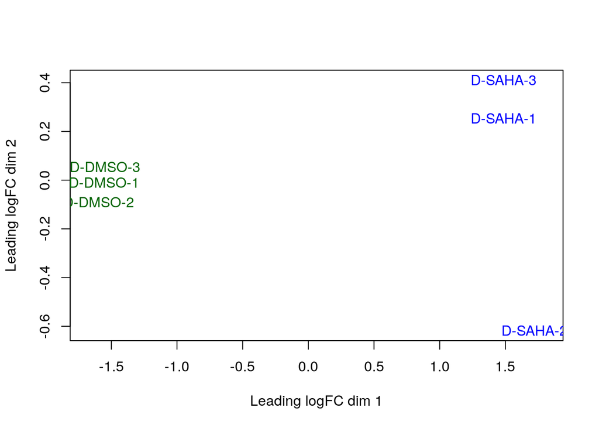

```r
plotMDS(d, labels=rownames(samples),
  col = c("darkgreen","blue")[factor(samples$treatment)])
```

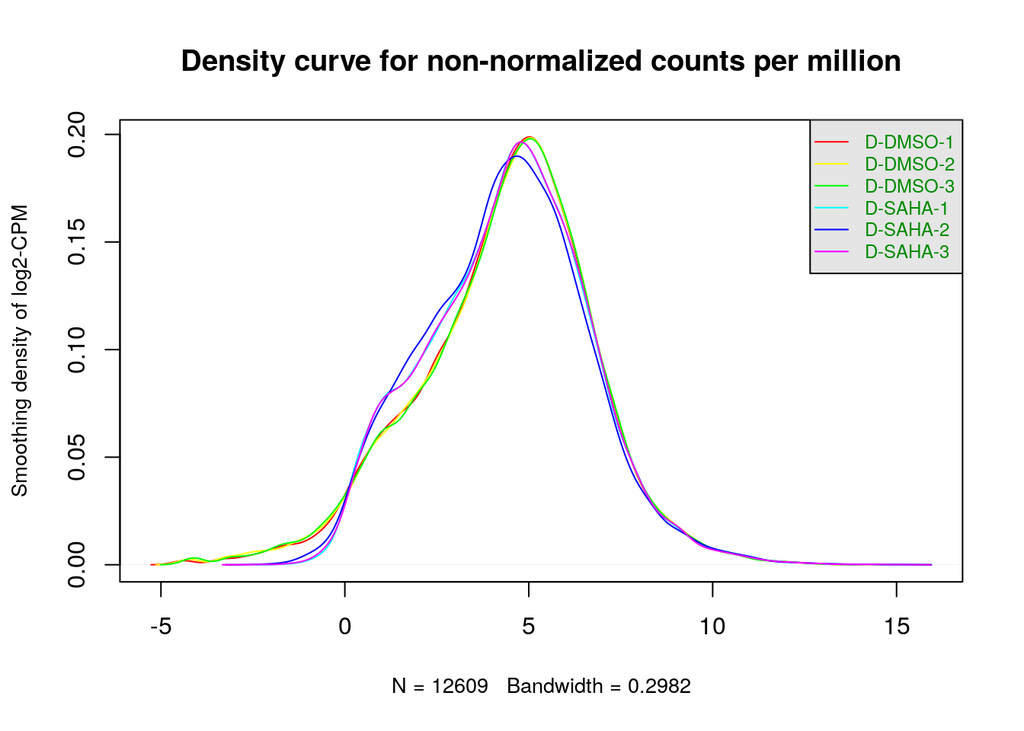

```r
#PLOT NON-NORMALIZED DATA
#Distribution of our data - Density plot
counts_density <- apply(log2(cpm(diabetic.SAHA.DMSO.filtered[,2:ncol(diabetic.SAHA.DMSO.filtered)])), 2, density)
#calculate the limits across all the samples
xlim <- 0; ylim <- 0
for (i in 1:length(counts_density)) {
  xlim <- range(c(xlim, counts_density[[i]]$x));
  ylim <- range(c(ylim, counts_density[[i]]$y))
}
cols <- rainbow(length(counts_density))
ltys <- rep(1, length(counts_density))
#plot the first density plot to initialize the plot
plot(counts_density[[1]], xlim=xlim, ylim=ylim, type="n",
     ylab="Smoothing density of log2-CPM", main="Density curve for non-normalized counts per million", cex.lab = 0.85)
#plot each line
for (i in 1:length(counts_density)) lines(counts_density[[i]], col=cols[i], lty=ltys[i])
#create legend
legend("topright", rownames(samples),
       col=cols, lty=ltys, cex=0.75,
       border ="blue",  text.col = "green4",
       merge = TRUE, bg = "gray90")
```

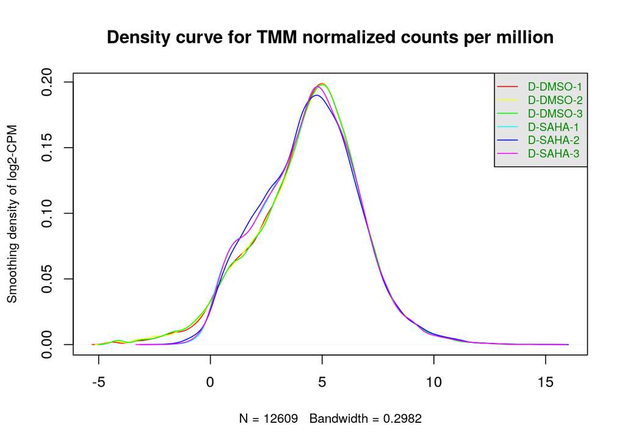

```r
#PLOT NORMALIZED DATA

counts_density <- apply(log2(cpm(d)), 2, density)
#calculate the limits across all the samples
xlim <- 0; ylim <- 0
for (i in 1:length(counts_density)) {
  xlim <- range(c(xlim, counts_density[[i]]$x));
  ylim <- range(c(ylim, counts_density[[i]]$y))
}
cols <- rainbow(length(counts_density))
ltys <- rep(1, length(counts_density))
#plot the first density plot to initialize the plot
plot(counts_density[[1]], xlim=xlim, ylim=ylim, type="n",
     ylab="Smoothing density of log2-CPM", main="Density curve for TMM normalized counts per million", cex.lab = 0.85)
#plot each line
for (i in 1:length(counts_density)) lines(counts_density[[i]], col=cols[i], lty=ltys[i])
#create legend
legend("topright", rownames(samples),
       col=cols, lty=ltys, cex=0.75,
       border ="blue",  text.col = "green4",
       merge = TRUE, bg = "gray90")
```

```r
#identical(cpm(diabetic.SAHA.DMSO.filtered[,2:ncol(diabetic.SAHA.DMSO.filtered)]), cpm(d$counts))
```

NORMALIZATION

-In the paper, it is stated that" …(aligned using) STAR. The tool feature Counts was used to generate a matrix of read counts per gene and the edgeR software was then used to determine differential gene expression“, and also”Gene expression changes were determined by normalizing against HPRT1." [1]  
-It seems like normalization has already been done on these samples, since upon TMM normalization of the data, there is only a very minimal shift in density curves

```r
#estimate common and tagwise dispersion, model_design not used since there is only 1 dimension (i.e. cell type)
d <- estimateDisp(d)
```

```
## Design matrix not provided. Switch to the classic mode.
```

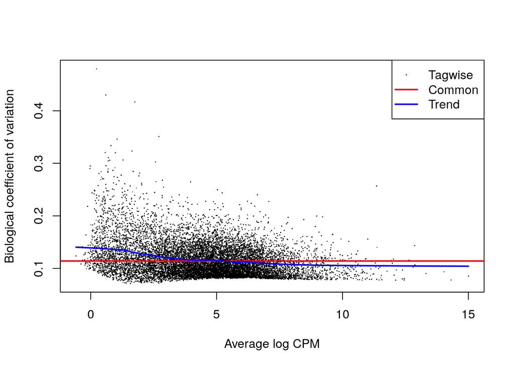

```r
plotBCV(d,col.tagwise = "black",col.common = "red")
```

Final data frame “final.df”. As specified in the assignment, this data frame has x=6 numeric columns, one for each sample, and the rownames are HGNC symbols obtained from biomaRt. ENSG IDs are not included in the data frame, since this would result in 1 non-numeric column. Rows which did not have a corresponding HGNC symbol were removed, since unique HGNC rownames could not be given if they are included.

```r
final.df <- log2(cpm(d))
```

```r
#compile R notebook
#rmarkdown::render('assignment1.Rmd', output_format = 'html_document')
```

# Remaining interpretation questions

**How did you handle replicates?**  
I have 6 samples, and split them into 2 groups: 3 replicates for DMSO treatment and 3 replicates for SAHA treatment.

**Were there expression values that were not unique for specific genes? How did you handle these?**  
No, there were not duplicate HGNC identifiers.

**How many outliers were removed?**  
I did not remove outliers

**What is the final coverage of your dataset?**  
The final coverage is 12609 HGNC rows in my final data frame.

## References

[1] Rafehi H, Kaspi A, Ziemann M, Okabe J, Karagiannis TC, El-Osta A. “Systems approach to the pharmacological actions of HDAC inhibitors reveals EP300 activities and convergent mechanisms of regulation in diabetes.” Epigenetics. 2017;12(11):991-1003. doi: 10.1080/15592294.2017.1371892.